# Iris Data Analysis Report

## Contents

1. Logistic Regression
2. K - Nearest Neighbour KNN
3. Support Vector Machine SVM

```python
import pandas as pd
import numpy as np
import matplotlib.pyplot as plt
```

```python
df = pd.read_csv("dataset/Iris.csv")
df.head(5)
```

|  | Id | SepalLengthCm | SepalWidthCm | PetalLengthCm | PetalWidthCm | Species |
| --- | --- | --- | --- | --- | --- | --- |
| 0 | 1 | 5.1 | 3.5 | 1.4 | 0.2 | Iris-setosa |
| 1 | 2 | 4.9 | 3.0 | 1.4 | 0.2 | Iris-setosa |
| 2 | 3 | 4.7 | 3.2 | 1.3 | 0.2 | Iris-setosa |
| 3 | 4 | 4.6 | 3.1 | 1.5 | 0.2 | Iris-setosa |
| 4 | 5 | 5.0 | 3.6 | 1.4 | 0.2 | Iris-setosa |

### Date From : https://www.kaggle.com/uciml/iris

- Id : Unique number assigned to each Iris
- SepalLengthCm : Length of Sepal in cm
- SepalWidtdCm : Width of Sepal in cm
- PetalLengthCm : Length of Petal in cm
- PetalWidthCm : Width of Petal in cm
- Species : Species of Iris

```python
## basic statics for Iris data set
df.describe()
```

|  | Id | SepalLengthCm | SepalWidthCm | PetalLengthCm | PetalWidthCm |
| --- | --- | --- | --- | --- | --- |
| count | 150.000000 | 150.000000 | 150.000000 | 150.000000 | 150.000000 |
| mean | 75.500000 | 5.843333 | 3.054000 | 3.758667 | 1.198667 |
| std | 43.445368 | 0.828066 | 0.433594 | 1.764420 | 0.763161 |
| min | 1.000000 | 4.300000 | 2.000000 | 1.000000 | 0.100000 |
| 25% | 38.250000 | 5.100000 | 2.800000 | 1.600000 | 0.300000 |
| 50% | 75.500000 | 5.800000 | 3.000000 | 4.350000 | 1.300000 |
| 75% | 112.750000 | 6.400000 | 3.300000 | 5.100000 | 1.800000 |
| max | 150.000000 | 7.900000 | 4.400000 | 6.900000 | 2.500000 |

### Something we need to check here:

- whether min/max is too small or large compared to other observations which might be one of outliers

```python
# check Datetype and whether there is null
df.info()
```

```
<class 'pandas.core.frame.DataFrame'>
RangeIndex: 150 entries, 0 to 149
Data columns (total 6 columns):
 #   Column         Non-Null Count  Dtype
---  ------         --------------  -----
 0   Id             150 non-null    int64
 1   SepalLengthCm  150 non-null    float64
 2   SepalWidthCm   150 non-null    float64
 3   PetalLengthCm  150 non-null    float64
 4   PetalWidthCm   150 non-null    float64
 5   Species        150 non-null    object
dtypes: float64(4), int64(1), object(1)
memory usage: 7.2+ KB
```

### Something we need to check here:

- how many observations do we have.
- Are there any Null-value count in each Column.
- Date types of each column, we should be able to convert them to other type for further data handling.

```python
# just in case, if I need to convert!

# Convert data type of Species to int
#df['Species'] = df['Species'].astype('category').cat.codes
#df.info()
```

```python
## Check for the types of Iris and its amount we have
from collections import Counter
Counter(df["Species"])
```

```
Counter({'Iris-setosa': 50, 'Iris-versicolor': 50, 'Iris-virginica': 50})
```

- We have three different types of Iris species, named as "Iris-setosa", "Iris-versicolor", "Iris-virginica" and they all have the same sample number (50).

[figure not shown]

  General information for each Iris species from Wikipedia

```python
# It seems like we don't need Id for further data analysis
df = df.iloc[:len(df), 1:] #Select all rows from 0 to whole except for last first column nemed "id"
df.head(5)
```

|  | SepalLengthCm | SepalWidthCm | PetalLengthCm | PetalWidthCm | Species |
| --- | --- | --- | --- | --- | --- |
| 0 | 5.1 | 3.5 | 1.4 | 0.2 | Iris-setosa |
| 1 | 4.9 | 3.0 | 1.4 | 0.2 | Iris-setosa |
| 2 | 4.7 | 3.2 | 1.3 | 0.2 | Iris-setosa |
| 3 | 4.6 | 3.1 | 1.5 | 0.2 | Iris-setosa |
| 4 | 5.0 | 3.6 | 1.4 | 0.2 | Iris-setosa |

# Classfication

### 1. Divide data set into Train and Test set

```python
# SckitLearn also provide Test/Train set selection modules kindly!
from sklearn.model_selection import train_test_split

x_train,x_test,y_train,y_test = train_test_split(df.iloc[:len(df), :-1], df.iloc[:len(df), -1],test_size=0.2)
x_train.head(5)
```

|  | SepalLengthCm | SepalWidthCm | PetalLengthCm | PetalWidthCm |
| --- | --- | --- | --- | --- |
| 78 | 6.0 | 2.9 | 4.5 | 1.5 |
| 32 | 5.2 | 4.1 | 1.5 | 0.1 |
| 106 | 4.9 | 2.5 | 4.5 | 1.7 |
| 85 | 6.0 | 3.4 | 4.5 | 1.6 |
| 2 | 4.7 | 3.2 | 1.3 | 0.2 |

```python
Counter(y_train)
```

```
Counter({'Iris-versicolor': 43, 'Iris-setosa': 39, 'Iris-virginica': 38})
```

We will split our Iris data set as train/test sets by 8:2. Therefore, we will fit the model with train set first, then we will test them with test set. It seems like each species divided fairly into similar number of train/test set.

### 1.1 Classify Iris Species by Sepal Length and Width

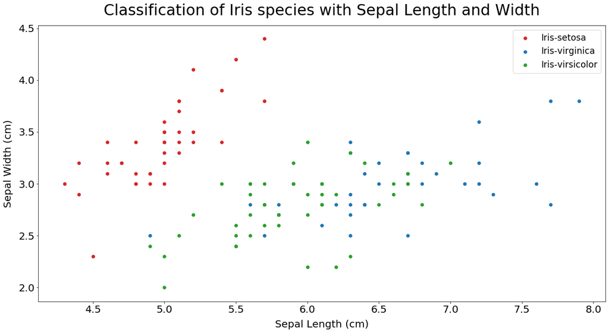

```python
# Set Plot Size
plt.figure(figsize=(20, 10))

## Set Variables
plt.scatter(x_train["SepalLengthCm"].loc[y_train=="Iris-setosa"], x_train["SepalWidthCm"].loc[y_train=="Iris-setosa"],
            c="tab:red", label="Iris-setosa")
plt.scatter(x_train["SepalLengthCm"].loc[y_train=="Iris-virginica"], x_train["SepalWidthCm"].loc[y_train=="Iris-virginica"],
            c="tab:blue", label="Iris-virginica")
plt.scatter(x_train["SepalLengthCm"].loc[y_train=="Iris-versicolor"], x_train["SepalWidthCm"].loc[y_train=="Iris-versicolor"],
            c="tab:green", label="Iris-virsicolor")

## plot Labelling
plt.title('Classification of Iris species with Sepal Length and Width',fontsize=30, pad=20) ## Title Labelling
plt.xlabel("Sepal Length (cm)", fontsize = 20, labelpad=10) ## X-axis Labelling
plt.ylabel("Sepal Width (cm)", fontsize = 20, labelpad=10) ## Y-axis Labelling

plt.xticks(fontsize = 20)
plt.yticks(fontsize = 20)

## Plot legnd
plt.legend(fontsize="xx-large")
```

## 1.1.1 Classification with Logistic Regression Method

```python
from sklearn.preprocessing import StandardScaler

sc = StandardScaler()

x_train1 = sc.fit_transform(x_train[["SepalLengthCm","SepalWidthCm"]])
x_test1 = sc.transform(x_test[["SepalLengthCm","SepalWidthCm"]])
```

```python
from sklearn.linear_model import LogisticRegression

Model1 = LogisticRegression(random_state = 0)
Model1.fit(x_train1, y_train)
y_pred1 = Model1.predict(x_test1)
y_pred1
```

```
array(['Iris-virginica', 'Iris-setosa', 'Iris-setosa', 'Iris-virginica',
       'Iris-setosa', 'Iris-versicolor', 'Iris-virginica',
       'Iris-versicolor', 'Iris-virginica', 'Iris-setosa', 'Iris-setosa',
       'Iris-virginica', 'Iris-virginica', 'Iris-versicolor',
       'Iris-setosa', 'Iris-setosa', 'Iris-virginica', 'Iris-virginica',
       'Iris-virginica', 'Iris-setosa', 'Iris-virginica', 'Iris-setosa',
       'Iris-versicolor', 'Iris-versicolor', 'Iris-setosa',
       'Iris-virginica', 'Iris-virginica', 'Iris-virginica',
       'Iris-versicolor', 'Iris-setosa'], dtype=object)
```

## 1.1.2 Confusion Matrix and Accuracy

```python
from sklearn.metrics import confusion_matrix, accuracy_score

acc =  accuracy_score(y_test, y_pred1)
cm = confusion_matrix(y_test, y_pred1)

print(acc)
print(cm)
```

```
0.8333333333333334
[[11  0  0]
 [ 0  4  3]
 [ 0  2 10]]
```

```
Confusion matrix, without normalization
[[11  0  0]
 [ 0  4  3]
 [ 0  2 10]]
Normalized confusion matrix
[[1.         0.         0.        ]
 [0.         0.57142857 0.42857143]
 [0.         0.16666667 0.83333333]]
```

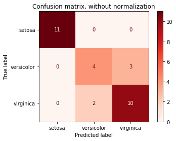

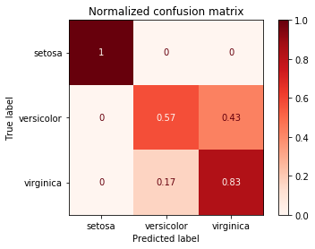

```python
from sklearn.metrics import plot_confusion_matrix

class_names = ['setosa', 'versicolor', 'virginica']
classifier = Model1.fit(x_train1, y_train)

# Plot non-normalized confusion matrix
titles_options = [("Confusion matrix, without normalization", None),
                  ("Normalized confusion matrix", 'true')]
for title, normalize in titles_options:
    disp = plot_confusion_matrix(classifier, x_test1, y_test,
                                 display_labels=class_names,
                                 cmap=plt.cm.Reds,
                                 normalize=normalize)
    disp.ax_.set_title(title)

    print(title)
    print(disp.confusion_matrix)

plt.show()
```

### 1.2 Classify Iris Species by Petal Length and Width

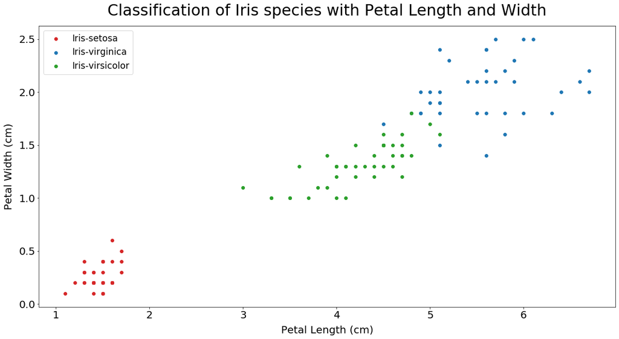

```python
# Set Plot Size
plt.figure(figsize=(20, 10))

## Set Variables
plt.scatter(x_train["PetalLengthCm"].loc[y_train=="Iris-setosa"], x_train["PetalWidthCm"].loc[y_train=="Iris-setosa"],
            c="tab:red", label="Iris-setosa")
plt.scatter(x_train["PetalLengthCm"].loc[y_train=="Iris-virginica"], x_train["PetalWidthCm"].loc[y_train=="Iris-virginica"],
            c="tab:blue", label="Iris-virginica")
plt.scatter(x_train["PetalLengthCm"].loc[y_train=="Iris-versicolor"], x_train["PetalWidthCm"].loc[y_train=="Iris-versicolor"],
            c="tab:green", label="Iris-virsicolor")

## Plot Labelling
plt.title('Classification of Iris species with Petal Length and Width',fontsize=30, pad=20) ## Title Labelling
plt.xlabel("Petal Length (cm)", fontsize = 20, labelpad=10) ## X-axis Labelling
plt.ylabel("Petal Width (cm)", fontsize = 20, labelpad=10) ## Y-axis Labelling

plt.xticks(fontsize = 20)
plt.yticks(fontsize = 20)

## Plot legnd
plt.legend(fontsize="xx-large")
```

```python
from sklearn.preprocessing import StandardScaler

sc = StandardScaler()

x_train2 = sc.fit_transform(x_train[["PetalLengthCm","PetalWidthCm"]])
x_test2 = sc.transform(x_test[["PetalLengthCm","PetalWidthCm"]])
```

```python
from sklearn.linear_model import LogisticRegression

Model2 = LogisticRegression(random_state = 0)
Model2.fit(x_train2, y_train)
y_pred2 = Model2.predict(x_test2)
y_pred2
```

```
array(['Iris-virginica', 'Iris-setosa', 'Iris-setosa', 'Iris-virginica',
       'Iris-setosa', 'Iris-versicolor', 'Iris-virginica',
       'Iris-versicolor', 'Iris-virginica', 'Iris-setosa', 'Iris-setosa',
       'Iris-versicolor', 'Iris-virginica', 'Iris-versicolor',
       'Iris-setosa', 'Iris-setosa', 'Iris-versicolor', 'Iris-virginica',
       'Iris-virginica', 'Iris-setosa', 'Iris-virginica', 'Iris-setosa',
       'Iris-versicolor', 'Iris-versicolor', 'Iris-setosa',
       'Iris-virginica', 'Iris-virginica', 'Iris-versicolor',
       'Iris-virginica', 'Iris-setosa'], dtype=object)
```

### 1.2.1 Confusion Matrix and Accuracy

```python
from sklearn.metrics import confusion_matrix, accuracy_score

acc =  accuracy_score(y_test, y_pred2)
cm = confusion_matrix(y_test, y_pred2)

print(acc)
print(cm)
```

```
0.9666666666666667
[[11  0  0]
 [ 0  7  0]
 [ 0  1 11]]
```

```
Confusion matrix, without normalization
[[11  0  0]
 [ 0  7  0]
 [ 0  1 11]]
Normalized confusion matrix
[[1.         0.         0.        ]
 [0.         1.         0.        ]
 [0.         0.08333333 0.91666667]]
```

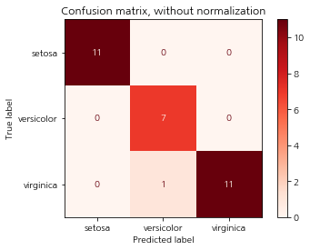

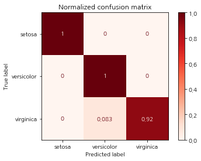

```python
from sklearn.metrics import plot_confusion_matrix

class_names = ['setosa', 'versicolor', 'virginica']
classifier = Model2.fit(x_train2, y_train)

# Plot non-normalized confusion matrix
titles_options = [("Confusion matrix, without normalization", None),
                  ("Normalized confusion matrix", 'true')]
for title, normalize in titles_options:
    disp = plot_confusion_matrix(classifier, x_test2, y_test,
                                 display_labels=class_names,
                                 cmap=plt.cm.Reds,
                                 normalize=normalize)
    disp.ax_.set_title(title)

    print(title)
    print(disp.confusion_matrix)

plt.show()
```

### Conclusion:

# What if we use all four explanatory variables ?

```
Confusion matrix, without normalization
[[11  0  0]
 [ 0  7  0]
 [ 0  0 12]]
Normalized confusion matrix
[[1. 0. 0.]
 [0. 1. 0.]
 [0. 0. 1.]]
```

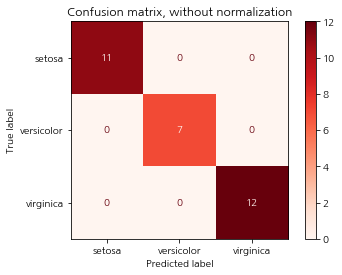

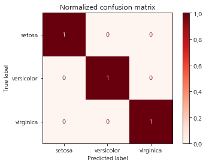

```python
from sklearn.metrics import plot_confusion_matrix

x_train = sc.fit_transform(x_train)
x_test = sc.transform(x_test)
Model = LogisticRegression(random_state = 0)
Model.fit(x_train1, y_train)
class_names = ['setosa', 'versicolor', 'virginica']
classifier = Model.fit(x_train, y_train)

# Plot non-normalized confusion matrix
titles_options = [("Confusion matrix, without normalization", None),
                  ("Normalized confusion matrix", 'true')]
for title, normalize in titles_options:
    disp = plot_confusion_matrix(classifier, x_test, y_test,
                                 display_labels=class_names,
                                 cmap=plt.cm.Reds,
                                 normalize=normalize)
    disp.ax_.set_title(title)

    print(title)
    print(disp.confusion_matrix)

plt.show()
```

## Conclusion:

It is hard to visualize as scatter plot like we did above for sepal and petal since we have 4 explanatory variables, but we still have chances to apply logistic regression method for classification. In this case, suprisely! all the test set has been correctly predicted as shown above. We will be able to say that both length and width of sepal and petal is highly related to classify the Iris species.

# 2. K-Nearest Neibours (KNN)

## 2.1 KNN method with 5-neighbours

```python
from sklearn.neighbors import KNeighborsClassifier

KNN_classifier = KNeighborsClassifier(n_neighbors=5)
KNN_classifier.fit(x_train, y_train)
```

```
KNeighborsClassifier(algorithm='auto', leaf_size=30, metric='minkowski',
                     metric_params=None, n_jobs=None, n_neighbors=5, p=2,
                     weights='uniform')
```

```python
y_pred3 = KNN_classifier.predict(x_test)
y_pred3
```

```
array(['Iris-virginica', 'Iris-setosa', 'Iris-setosa', 'Iris-virginica',
       'Iris-setosa', 'Iris-versicolor', 'Iris-virginica',
       'Iris-virginica', 'Iris-virginica', 'Iris-setosa', 'Iris-setosa',
       'Iris-versicolor', 'Iris-virginica', 'Iris-versicolor',
       'Iris-setosa', 'Iris-setosa', 'Iris-versicolor', 'Iris-virginica',
       'Iris-virginica', 'Iris-setosa', 'Iris-virginica', 'Iris-setosa',
       'Iris-versicolor', 'Iris-versicolor', 'Iris-setosa',
       'Iris-virginica', 'Iris-virginica', 'Iris-versicolor',
       'Iris-virginica', 'Iris-setosa'], dtype=object)
```

```python
from sklearn.metrics import confusion_matrix, accuracy_score

acc =  accuracy_score(y_test, y_pred3)
cm = confusion_matrix(y_test, y_pred3)

print(acc)
print(cm)
```

```
0.9333333333333333
[[11  0  0]
 [ 0  6  1]
 [ 0  1 11]]
```

## 2.1.1 Confusion Matrix and Accuracy

```
Confusion matrix, without normalization
[[11  0  0]
 [ 0  6  1]
 [ 0  1 11]]
Normalized confusion matrix
[[1.         0.         0.        ]
 [0.         0.85714286 0.14285714]
 [0.         0.08333333 0.91666667]]
```

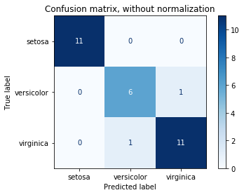

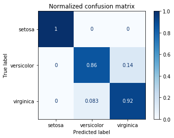

```python
from sklearn.metrics import plot_confusion_matrix

# Plot non-normalized confusion matrix
titles_options = [("Confusion matrix, without normalization", None),
                  ("Normalized confusion matrix", 'true')]
for title, normalize in titles_options:
    disp = plot_confusion_matrix(KNN_classifier, x_test, y_test,
                                 display_labels=class_names,
                                 cmap=plt.cm.Blues,
                                 normalize=normalize)
    disp.ax_.set_title(title)

    print(title)
    print(disp.confusion_matrix)

plt.show()
```

## Conclusion:

According to the result above, accuracy is quite high as we expected since we already showed that both petal and sepal is key characteristics of classifying Iris-Specis with logistic regression. As a comparison, the final result is not as good as logistics regression. However, in KNN method, we can adjust the number of neighbours and sometimes it increases the accuracy. For the next step, we will attempt those different number of neighbour to maximize our accuracy.

## 2.2 Neighbour selection of KNN method

## Let's increase the accuracy by choosing different N!

Since we have 120 observations in train set,it means that each observation have 119 neighbour around. The number of nearest neighbour is likely to be selected from 1 to 119, however, we have three different species in this case. Thus, 40 will be the maximum range we will see.

```python
KNN_list = []

for i in range(1,40):
    KNN_classifier_n = KNeighborsClassifier(n_neighbors=i)
    KNN_classifier_n.fit(x_train, y_train)
    y_pred3 = KNN_classifier_n.predict(x_test)
    acc =  accuracy_score(y_test, y_pred3)
    KNN_list.append(acc)
```

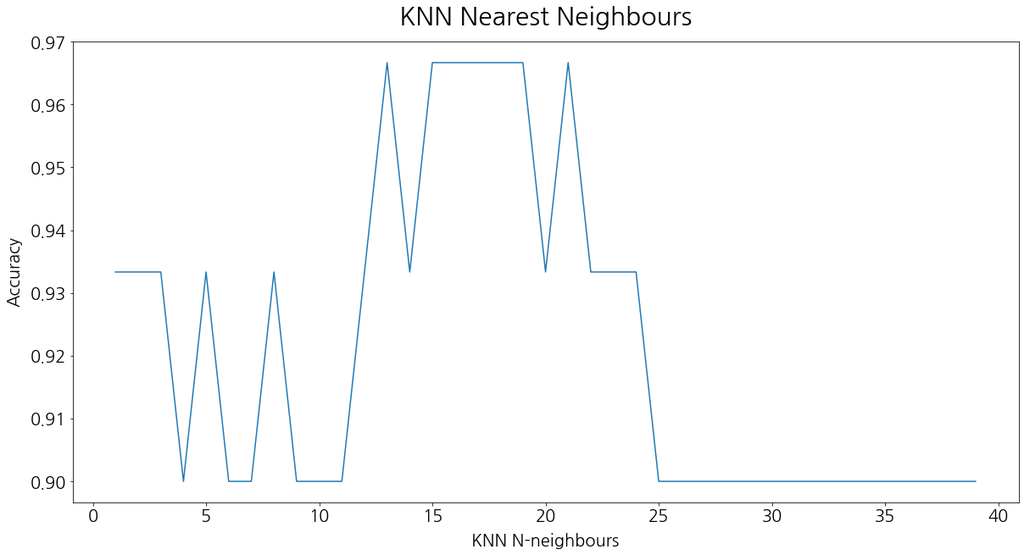

```python
y= KNN_list
x= list(range(1,40))

plt.figure(figsize=(20, 10))


plt.plot(x, y)

plt.title('KNN Nearest Neighbours',fontsize=30, pad=20)
plt.xlabel("KNN N-neighbours", fontsize = 20, labelpad=10)
plt.ylabel("Accuracy", fontsize = 20, labelpad=10)

plt.yticks(fontsize = 20)
plt.xticks(fontsize = 20)
plt.show()
```

```python
KNN = pd.DataFrame(KNN_list,list(range(1,40))).reset_index()
KNN.columns = ['N', "Accuracy"]
KNN[KNN["Accuracy"]==KNN["Accuracy"].max()]
```

|  | N | Accuracy |
| --- | --- | --- |
| 12 | 13 | 0.966667 |
| 14 | 15 | 0.966667 |
| 15 | 16 | 0.966667 |
| 16 | 17 | 0.966667 |
| 17 | 18 | 0.966667 |
| 18 | 19 | 0.966667 |
| 20 | 21 | 0.966667 |

## 2.2.1 Confusion Matrix and Accuracy

```
Confusion matrix, without normalization
[[11  0  0]
 [ 0  7  0]
 [ 0  1 11]]
Normalized confusion matrix
[[1.         0.         0.        ]
 [0.         1.         0.        ]
 [0.         0.08333333 0.91666667]]
```

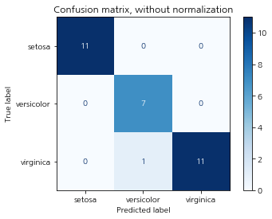

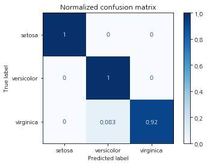

```python
from sklearn.metrics import plot_confusion_matrix

KNN_classifier = KNeighborsClassifier(n_neighbors=13)
KNN_classifier.fit(x_train, y_train)

# Plot non-normalized confusion matrix
titles_options = [("Confusion matrix, without normalization", None),
                  ("Normalized confusion matrix", 'true')]
for title, normalize in titles_options:
    disp = plot_confusion_matrix(KNN_classifier, x_test, y_test,
                                 display_labels=class_names,
                                 cmap=plt.cm.Blues,
                                 normalize=normalize)
    disp.ax_.set_title(title)

    print(title)
    print(disp.confusion_matrix)

plt.show()
```

## Conclusion

# 3. Support Vector Machine

## 3.1 SVM with Linear Kernel

```python
from sklearn import svm

SVM_Linear_clf = svm.SVC(kernel='linear')
SVM_Linear_clf.fit(x_train,y_train)
```

```
SVC(C=1.0, break_ties=False, cache_size=200, class_weight=None, coef0=0.0,
    decision_function_shape='ovr', degree=3, gamma='scale', kernel='linear',
    max_iter=-1, probability=False, random_state=None, shrinking=True,
    tol=0.001, verbose=False)
```

```python
y_pred4 = SVM_Linear_clf.predict(x_test)
y_pred4
```

```
array(['Iris-virginica', 'Iris-setosa', 'Iris-setosa', 'Iris-virginica',
       'Iris-setosa', 'Iris-versicolor', 'Iris-virginica',
       'Iris-versicolor', 'Iris-virginica', 'Iris-setosa', 'Iris-setosa',
       'Iris-versicolor', 'Iris-virginica', 'Iris-versicolor',
       'Iris-setosa', 'Iris-setosa', 'Iris-versicolor', 'Iris-virginica',
       'Iris-virginica', 'Iris-setosa', 'Iris-virginica', 'Iris-setosa',
       'Iris-versicolor', 'Iris-virginica', 'Iris-setosa',
       'Iris-virginica', 'Iris-virginica', 'Iris-versicolor',
       'Iris-virginica', 'Iris-setosa'], dtype=object)
```

## 3.1.1 Confusion Matrix and Accuracy

```python
from sklearn.metrics import confusion_matrix, accuracy_score

acc =  accuracy_score(y_test, y_pred4)
cm = confusion_matrix(y_test, y_pred4)

print(acc)
print(cm)
```

```
1.0
[[11  0  0]
 [ 0  7  0]
 [ 0  0 12]]
```

```
Confusion matrix, without normalization
[[11  0  0]
 [ 0  7  0]
 [ 0  0 12]]
Normalized confusion matrix
[[1. 0. 0.]
 [0. 1. 0.]
 [0. 0. 1.]]
```

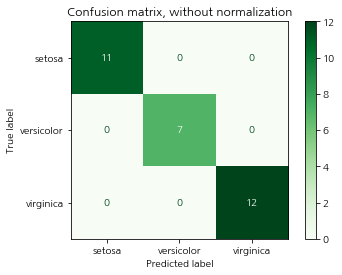

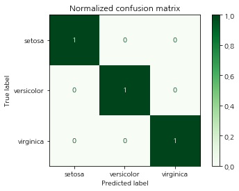

```python
from sklearn.metrics import plot_confusion_matrix

SVM_Linear_clf = svm.SVC(kernel='linear')
SVM_Linear_clf = SVM_Linear_clf.fit(x_train,y_train)

# Plot non-normalized confusion matrix
titles_options = [("Confusion matrix, without normalization", None),
                  ("Normalized confusion matrix", 'true')]
for title, normalize in titles_options:
    disp = plot_confusion_matrix(SVM_Linear_clf, x_test, y_test,
                                 display_labels=class_names,
                                 cmap=plt.cm.Greens,
                                 normalize=normalize)
    disp.ax_.set_title(title)

    print(title)
    print(disp.confusion_matrix)

plt.show()
```

## 3.2 SVM with Polynomial Kernel

```
Confusion matrix, without normalization
[[11  0  0]
 [ 0  7  0]
 [ 0  1 11]]
Normalized confusion matrix
[[1.         0.         0.        ]
 [0.         1.         0.        ]
 [0.         0.08333333 0.91666667]]
```

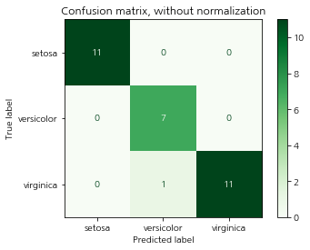

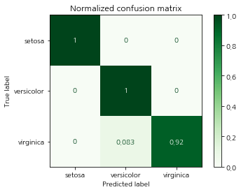

```python
from sklearn.metrics import plot_confusion_matrix

SVM_Linear_clf = svm.SVC(kernel='poly')
SVM_Linear_clf = SVM_Linear_clf.fit(x_train,y_train)

# Plot non-normalized confusion matrix
titles_options = [("Confusion matrix, without normalization", None),
                  ("Normalized confusion matrix", 'true')]
for title, normalize in titles_options:
    disp = plot_confusion_matrix(SVM_Linear_clf, x_test, y_test,
                                 display_labels=class_names,
                                 cmap=plt.cm.Greens,
                                 normalize=normalize)
    disp.ax_.set_title(title)

    print(title)
    print(disp.confusion_matrix)

plt.show()
```

## Conclusion:

# Final Conclusion:

our data set contains 150 Irises in total with sepal length and width in cm, and also petal length and width in cm. Each iris observations have information about their speciesc as well. Therefore, all the 150 irises in data set is divided fairly into three different species with the same number,50, namly, setosa, virsicolor and virginica. Our goal is running several machine learning methods to classify iris, and find the best method.

Firstly, we need to arrange our date set before we start any analysis. That means, we need to find any missing values or some typos as well. First few steps show that our data set is already managed clearly without any missing values and it seems like every observed values are quite well-distributed.

Visualizing data is helpful and sometimes it is crucial. Since it is not possible to draw high dimension plots, I divided each observations as petal and sepal section and plotted them as two different scatter plots. If we look at scatter plot of sepal lengh and width, Iris-setosa is clearly separated away from the other two species,but it is not clear enough to say for the other two species. However if we move to petal section, it becomes much clearer and three species seem like they have thier own positions.

To find the best method, we need to test them and verify whether their modelling formula is better than other methods. Thus, we will split our data set into test and training data set. We will use the traning set as fitting model with selected machine learning method, and test set as testing them whether thier model fits well in test set.

At last, both SVM method with linear kernel and logisitic regression show 100% corredcted prediction after testing. Even so, other methods also show high accuracy with at least 80%. So, the four different variables of length and width of sepal and petal can be used as characteristics to classify these three iris species.

# references:

<1. Logistic Regression>

- https://teddykoker.com/2019/06/multi-class-classification-with-logistic-regression-in-python/
- https://scikit-learn.org/stable/auto_examples/model_selection/plot_confusion_matrix.html#sphx-glr-auto-examples-model-selection-plot-confusion-matrix-py

<2. KNN method>

- https://stackabuse.com/k-nearest-neighbors-algorithm-in-python-and-scikit-learn/
- https://scikit-learn.org/stable/modules/neighbors.html

<3. SVM method>

- https://scikit-learn.org/stable/modules/generated/sklearn.svm.SVC.html